# HOMEWORK 1 - PCA & Bayesian Classifier

PIERO CAVALCANTI - S252117 - 2018/2019

```python
# -*- coding: utf-8 -*-

print (__doc__)

from mpl_toolkits.mplot3d import Axes3D

from PIL import Image
from sklearn import preprocessing
from sklearn.model_selection import train_test_split
from sklearn.naive_bayes import GaussianNB
#from mlxtend.plotting import plot_decision_regions
from sklearn.decomposition import PCA
import numpy as np
import matplotlib.pyplot as plt
import matplotlib.colors as colours
import glob
import os
from random import randrange
from sys import getsizeof
```

```
Automatically created module for IPython interactive environment
```

## 1. Data Preparation

This stage allows to import the image set and treat it as a numeric matrix with dimension *<#ofImage x width x height x RGB>* == (1086,227,227,3), thanks to the use of glob, os and numpy packages. Furthermore, it will be created a label vector with *n* label values to perform classification with Naive Bayes Classifier.

```python
#LOAD IMAGES
#C:\Users\pcava\Desktop\Università\2_II_MachineLearning\homeworks\homework1\PACS_homework\dog
image_list = glob.glob("C:/Users/pcava/Desktop/Università/2_II_MachineLearning/homeworks/homework1/PACS_homework/*/*.jpg")
dog_list = glob.glob("C:/Users/pcava/Desktop/Università/2_II_MachineLearning/homeworks/homework1/PACS_homework/dog/*.jpg")
guitar_list = glob.glob("C:/Users/pcava/Desktop/Università/2_II_MachineLearning/homeworks/homework1/PACS_homework/guitar/*.jpg")
house_list = glob.glob("C:/Users/pcava/Desktop/Università/2_II_MachineLearning/homeworks/homework1/PACS_homework/house/*.jpg")
person_list = glob.glob("C:/Users/pcava/Desktop/Università/2_II_MachineLearning/homeworks/homework1/PACS_homework/person/*.jpg")

ne_1=len(os.listdir("C:/Users/pcava/Desktop/Università/2_II_MachineLearning/homeworks/homework1/PACS_homework/dog"))
ne_2=len(os.listdir("C:/Users/pcava/Desktop/Università/2_II_MachineLearning/homeworks/homework1/PACS_homework/guitar"))
ne_3=len(os.listdir("C:/Users/pcava/Desktop/Università/2_II_MachineLearning/homeworks/homework1/PACS_homework/house"))
ne_4=len(os.listdir("C:/Users/pcava/Desktop/Università/2_II_MachineLearning/homeworks/homework1/PACS_homework/person"))

i= 0

image_matrix = np.zeros((1086,227,227,3), dtype=int)

for image in image_list:
    image_matrix[i] = np.asarray(Image.open( image ))
    i=i+1

X = np.zeros((1086,154587),dtype=int)
y=np.zeros((1086),dtype=int)
for j in range(i):
    X[j] = image_matrix[j].ravel()
    if j < ne_1:
        y[j]=1
    elif j < ne_1 + ne_2:
        y[j]=2
    elif j < ne_1 + ne_2 + ne_3:
        y[j]=3
    else:
        y[j]=4
    j=j+1

print (X.shape)
print(y.shape)

#just 100 image randomly selected

#X = np.zeros((400,154587),dtype=int)
#for j in range(100):
#    X[j] = image_matrix[j].ravel()
#    X[100+j] = image_matrix[ne_1+j].ravel()
#    X[200+j] = image_matrix[ne_2+j].ravel()
#    X[300+j] = image_matrix[ne_3+j].ravel()
```

```
(1086, 154587)
(1086,)
```

## 2. Principal Components Visualization

This stage is related to PCA and all operation to work with that method. It will be studied by using both graphical plot and image reconstruction, to see this technique with a mathematical and practical point of view.

```
Clipping input data to the valid range for imshow with RGB data ([0..1] for floats or [0..255] for integers).
Clipping input data to the valid range for imshow with RGB data ([0..1] for floats or [0..255] for integers).
```

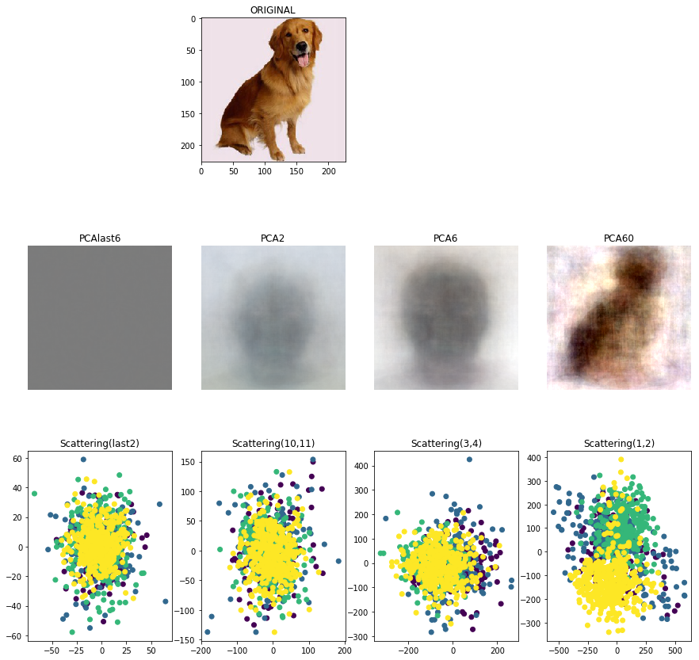

```python
fig = plt.figure(figsize=(15,15))
plt.axis('off')
plt.subplot(3,4,2).set_title("ORIGINAL")
plt.imshow(image_matrix[45])
#it will plot the original image to make possible a comparison with the compressed versions

#data normalization
X_mean= np.mean(X)
X_stddev= np.std(X)
X_norm = (X - X_mean) / X_stddev

#PCA function
ipca = PCA()
ipca.fit(X_norm)

j=4
j+=1
X_T = np.dot(X_norm, ipca.components_[-6:-1].T)
X_REVERSE = np.dot(X_T, ipca.components_[-6:-1])
X_REVERSE = (X_REVERSE*X_stddev) + X_mean
plt.subplot(3,4,j).set_title("PCAlast6")
plt.axis('off')
plt.imshow(X_REVERSE[45].reshape(227,227,3)/255)
for i in [2,6,60]:
    j+=1
    X_T = np.dot(X_norm, ipca.components_[0:i].T)
    X_REVERSE = np.dot(X_T, ipca.components_[0:i])
    X_REVERSE = (X_REVERSE*X_stddev) + X_mean
    plt.subplot(3,4,j).set_title("PCA"+str(i))
    plt.axis('off')
    plt.imshow(X_REVERSE[45].reshape(227,227,3)/255)



j+=1
plt.subplot(3,4,j).set_title("Scattering(last2)")
plt.scatter(X_T[:,-2],X_T[:,-1],c=y)
j+=1
plt.subplot(3,4,j).set_title("Scattering(10,11)")
plt.scatter(X_T[:,9],X_T[:,10],c=y)
j+=1
plt.subplot(3,4,j).set_title("Scattering(3,4)")
plt.scatter(X_T[:,2],X_T[:,3],c=y)
j+=1
plt.subplot(3,4,j).set_title("Scattering(1,2)")
plt.scatter(X_T[:,0],X_T[:,1],c=y)


plt.show()
```

**Repeat this exercise when considering third and fourth principal component, and then tenth and eleventh. What do you notice? Justify your answer from theoretical perspective behind PCA.**

PCA is a procedure that convert each instance of the dataset into its **principal components**: the first principal component has the largest possible variance, while the succeeding ones in turn has the highest variance possible under the constraint that it is orthogonal to the preceding components. Variance, informally, measures how far a set of values are spread out from their average value. So it, in short words, works as "summary" of the data designed to preserve the maximum informations possible with the dimensionality reduction choosen.

The graphs behind are a good representations of the concepts here described: the more the selected components get closer to the principal ones, the wider data-points *split* on the graph, and its depends on the maximized variance obtained thanks to PCAnalysis. It can be noticed looking at the axis values of the graphs, that grows up from the left to the right in the image behind.

Why it is so important? Well, despite the image representations do not represent excellently this usefull compression, PCA perform the best information compression for machine learning classifiers, that need to work on well-discriminated datas to obtain the best results possible.

**5. How would you decide on the number of principal components needed to preserve data without much distortion?**

There are two significant approaches to perform decision on the number of PC needed to "preserve" data: the most empirical regards the image visualization and follow the reasoning according to the choise has to be made based on the result, or rather the decision depends on how "good" is the visualization of reconstructed images, without considering the mathematical aspect of the problem.

The most significant approach is to choose a reasonable value for cumulative variance and taking the principal components consequently; e.g. taking the first k eigenvectors that capture at least 85% of the total variance.

In the graph below it is illustrated the ratio between the cumulative variance and the number of principal components, and immediately after is showed the choosen number of principal components following an heuristic like the one described above.

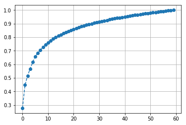

```
Good Number of PC= 27 with Cumulative Variance = 0.900120683559679
```

```python
explained_variance = np.var(X_T, axis=0)
explained_variance_ratio = explained_variance / np.sum(explained_variance)
cum=np.cumsum(explained_variance_ratio)
plt.plot(cum,'--o')
plt.grid(True)
plt.show()
desired=np.argmax(cum>0.9)
print("Good Number of PC=",desired,"with Cumulative Variance =",cum[desired])
```

## 2. Naive Bayes Classifier

In this stage, we will see how dimensionality reduction using PCA works when applied together with a machine learning classifier. We will use the Naive Bayes Classifier both on original dataset and dataset projected on two components extracted through PCA method.

#### Formulation:

$$\tilde{y} = \underset{y \in 1,2,3,4}{argmax} \ P(y | x_1, x_2,.., x_d) = \underset{y \in 1,2,3,4}{argmax} \ P(y) \prod_{i=1}^{d} P(x_i | y) = \underset{y \in 1,2,3,4}{argmax} \ \frac{1}{4}\prod_{i=1}^{d}\frac{1}{\sqrt{2\pi\sigma_y^2}} e^{-\frac{(x_i - \mu_y)^2}{ 2\sigma_y^2}} $$

```
###unmodified images
accuracy= 0.7522935779816514 for original-dimension images
Matrix Dimension (in kB): 1311574.078125
***
###PCA w/ 2 first components
accuracy= 0.6513761467889908 for #PC= 2  accuracy ratio respect to original ->  86.58536585365853 %
Matrix Dimension (in kB): 16.96875
Dimension ratio of PCA-compressed matrix respect to the original image matrix -> 0.0013021089590481132 %
***
###PCA w/ 3d & 4th component
accuracy= 0.47706422018348627 for #PC= 2 (3rd & 4th)  accuracy ratio respect to original ->  63.41463414634146 %
Matrix Dimension (in kB): 16.96875
Dimension ratio of PCA-compressed matrix respect to the original image matrix -> 0.0013021089590481132 %
```

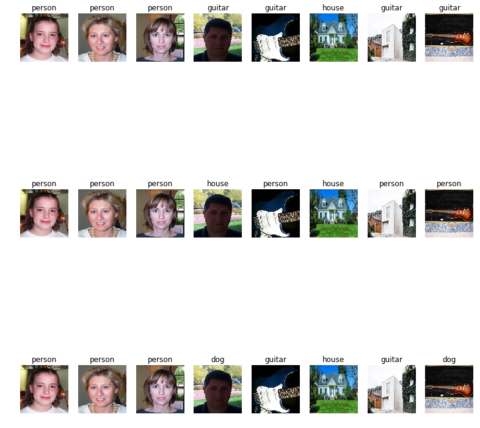

```python
# ------------------------------NB-CLASSIFIER-----------------------------------#
y_out = ["","dog","guitar","house","person","","",""]
rs1=78

###unmodified images
print("###unmodified images")
X_train, X_test, y_train, y_test = train_test_split(X_norm,y,test_size=0.1,random_state=rs1)
fig = plt.figure(figsize=(15,15))
gnb = GaussianNB()
X_test_d = (X_test*X_stddev) + X_mean

gnb.fit(X_train,y_train)
y_pred = gnb.predict(X_test)
original_gnb_acc=gnb.score(X_test,y_test)
print("accuracy=",original_gnb_acc,"for original-dimension images")
print("Matrix Dimension (in kB):",X_norm.nbytes/1024)
p=0
p+=1
#plt.subplot(3,9,p).set_title("DecisionReg")
#plot_decision_regions(X_test, y_test, clf=gnb, legend=2)
for i in [1,2,3,4,5,6,7,8]:
    p+=1
    plt.subplot(3,9,p).set_title(y_out[y_pred[i]])
    plt.axis('off')
    plt.imshow(X_test_d[i].reshape(227,227,3)/255)


print("***")
###PCA w/ 2 first components
print("###PCA w/ 2 first components")
X_T = np.dot(X_norm, ipca.components_[0:2].T)
X_train, X_test, y_train, y_test = train_test_split(X_T,y,test_size=0.1,random_state=rs1)
gnb.fit(X_train,y_train)
y_pred = gnb.predict(X_test)
print("accuracy=",gnb.score(X_test,y_test),"for #PC=",X_T.shape[1]," accuracy ratio respect to original -> ",100*gnb.score(X_test,y_test)/original_gnb_acc,"%")
print("Matrix Dimension (in kB):",X_T.nbytes/1024)
print("Dimension ratio of PCA-compressed matrix respect to the original image matrix ->",100*getsizeof(X_T)/getsizeof(X_norm),"%")
p+=1
#plt.subplot(3,9,p).set_title("DecisionReg")
#plot_decision_regions(X_T, y, clf=gnb, legend=2)
for i in [1,2,3,4,5,6,7,8]:
    p+=1
    plt.subplot(3,9,p).set_title(y_out[y_pred[i]])
    plt.axis('off')
    plt.imshow(X_test_d[i].reshape(227,227,3)/255)


print("***")
###PCA w/ 3d & 4th component
print("###PCA w/ 3d & 4th component")
X_T = np.dot(X_norm, ipca.components_[2:4].T)
X_train, X_test, y_train, y_test = train_test_split(X_T,y,test_size=0.1,random_state=rs1)
gnb.fit(X_train,y_train)
y_pred = gnb.predict(X_test)
print("accuracy=",gnb.score(X_test,y_test),"for #PC=",X_T.shape[1],"(3rd & 4th)"," accuracy ratio respect to original -> ",100*gnb.score(X_test,y_test)/original_gnb_acc,"%")
print("Matrix Dimension (in kB):",X_T.nbytes/1024)
print("Dimension ratio of PCA-compressed matrix respect to the original image matrix ->",100*getsizeof(X_T)/getsizeof(X_norm),"%")
p+=1
#plt.subplot(3,9,p).set_title("DecisionReg")
#plot_decision_regions(X_T, y, clf=gnb, legend=2)
for i in [1,2,3,4,5,6,7,8]:
    p+=1
    plt.subplot(3,9,p).set_title(y_out[y_pred[i]])
    plt.axis('off')
    plt.imshow(X_test_d[i].reshape(227,227,3)/255)


plt.show()
```

**4. Repeat the splitting, training, and testing for the data projected onto rst two principal components, then third and fourth principal components. Compare results: what are your conclusions?**

The stats printed behind briefly summarize the importance of the usage of PCA for dimension reduction: Principal components analysis allow us to reduct intensely the dimension of our dataset, with a minimum loss of information. In the example behind, we can see how PCA works in terms of:

-*information loss*: the accuracy of NB Classifier on prediction can easily represent a good example of the quality of PCA compression method. Our classifier, with the usage of the only first two principal components, can perform a good classification accuracy, which value generally stands between the 70% and 90% compared to the NB classifier accuracy using uncompressed images.

It means that, despite a huge compression of data using PCA, the classification algorithms could works with excellente results.